- Hi, this is the rmd file for project 2. We will be doing logistic regression to model food insecurity
- Lets start with the variables we selected for the first project. We should replace some variables I think, but we’ll do it along the way. I am just copying code from the first project for now. so we can get a base to build upon.

```
## 'data.frame':    71472 obs. of  11 variables:
##  $ States            : Factor w/ 51 levels "1","2","4","5",..: 1 1 1 1 1 1 1 1 1 1 ...
##  $ Family_Size       : Factor w/ 14 levels "1","2","3","4",..: 1 2 2 2 2 2 2 2 2 1 ...
##  $ Household_Income  : Factor w/ 16 levels "1","2","3","4",..: 16 14 14 12 12 13 13 9 9 11 ...
##  $ SNAP              : Factor w/ 5 levels "-3","-2","-1",..: 3 3 3 5 5 3 3 5 5 3 ...
##  $ Ethnicity         : Factor w/ 24 levels "1","2","3","4",..: 1 1 1 1 1 1 1 2 2 1 ...
##  $ Citizenship_status: Factor w/ 5 levels "1","2","3","4",..: 1 1 1 1 1 1 1 1 1 1 ...
##  $ Number_of_Jobs    : Factor w/ 4 levels "-1","2","3","4": 1 1 1 1 1 1 1 1 1 1 ...
##  $ Hours_on_Jobs     : Factor w/ 88 levels "-4","-1","0",..: 67 43 2 43 43 62 43 2 2 2 ...
##  $ Education_Level   : Factor w/ 17 levels "-1","31","32",..: 14 15 1 14 14 10 10 7 10 5 ...
##  $ Number_of_children: Factor w/ 12 levels "0","1","2","3",..: 1 2 1 1 1 1 1 1 1 1 ...
##  $ FoodSecurity_score: Factor w/ 4 levels "1","2","3","4": 1 1 1 1 1 1 1 2 2 1 ...
```

- Since we will be doing logistic regression, we have to reduce our response to two levels(binary). If we complete this project before the deadline we can look into multinomial regression as well.
- Trying to clean the data ang get the factors like ethnicity to work.

```r
table(FS_Subset$Ethnicity)
```

```
##
##                           White only                           Black only
##                                57253                                 7173
## American Indian, Alaskan native only                           Asian Only
##                                  952                                 3989
##                             Hawaiian                          White-black
##                                  329                                  531
##                             White-AI                          White-Asian
##                                  437                                  380
##                             White-HP                             Black-AI
##                                   68                                   72
##                          Black-Asian                             Black-HP
##                                   33                                    4
##                             AI-Asian                                AI-HP
##                                    8                                    1
##                             Asian-HP                               W-B-AI
##                                   58                                   51
##                                W-B-A                               W-B-HP
##                                   16                                    7
##                               W-AI-A                              W-AI-HP
##                                   10                                    6
##                               W-A-HP                               B-AI-A
##                                   72                                    3
##                             W-B-AL-A                            W-AI-A-HP
##                                    1                                   18
##                   Other 3 race combo             Other 4 and 5 race combo
##                                    0                                    0
```

```r
## Lets drop all levels that have less than 10 observations.

for(i in levels(FS_Subset$Ethnicity)) {
  if(count(subset(FS_Subset, Ethnicity == i)) < 10){
    print(i)
    FS_Subset <- FS_Subset[!(FS_Subset$Ethnicity %in% c(i)), ]
  }}
```

```
## [1] "Black-HP"
## [1] "AI-Asian"
## [1] "AI-HP"
## [1] "W-B-HP"
## [1] "W-AI-HP"
## [1] "B-AI-A"
## [1] "W-B-AL-A"
## [1] "Other 3 race combo"
## [1] "Other 4 and 5 race combo"
```

```r
FS_Subset$Ethnicity <- droplevels(FS_Subset$Ethnicity)

table(FS_Subset$Ethnicity)
```

```
##
##                           White only                           Black only
##                                57253                                 7173
## American Indian, Alaskan native only                           Asian Only
##                                  952                                 3989
##                             Hawaiian                          White-black
##                                  329                                  531
##                             White-AI                          White-Asian
##                                  437                                  380
##                             White-HP                             Black-AI
##                                   68                                   72
##                          Black-Asian                             Asian-HP
##                                   33                                   58
##                               W-B-AI                                W-B-A
##                                   51                                   16
##                               W-AI-A                               W-A-HP
##                                   10                                   72
##                            W-AI-A-HP
##                                   18
```

- Splitting the data

```r
set.seed(1)

sample <- sample(c(TRUE, FALSE), nrow(FS_Subset), replace = TRUE, prob = c(0.6, 0.4))

train <- FS_Subset[sample, ]
test  <- FS_Subset[!sample, ]

str(test)
```

```
## 'data.frame':    28636 obs. of  12 variables:
##  $ States            : Factor w/ 51 levels "1","2","4","5",..: 1 1 1 1 1 1 1 1 1 1 ...
##  $ Family_Size       : Factor w/ 14 levels "1","2","3","4",..: 2 2 2 2 2 2 1 3 3 2 ...
##  $ Household_Income  : Factor w/ 16 levels "1","2","3","4",..: 12 13 13 9 9 14 10 4 4 7 ...
##  $ SNAP              : Factor w/ 5 levels "-3","-2","-1",..: 5 3 3 5 5 3 5 5 5 3 ...
##  $ Ethnicity         : Factor w/ 17 levels "White only","Black only",..: 1 1 1 2 2 2 2 2 2 1 ...
##  $ Citizenship_status: Factor w/ 5 levels "NATIVE, BORN IN THE UNITED STATES",..: 1 1 1 1 1 1 1 1 1 1 ...
##  $ Number_of_Jobs    : Factor w/ 4 levels "-1","2","3","4": 1 1 1 1 1 1 1 1 1 1 ...
##  $ Hours_on_Jobs     : Factor w/ 88 levels "-4","-1","0",..: 43 62 43 2 2 43 43 2 2 2 ...
##  $ Education_Level   : Factor w/ 17 levels "-1","31","32",..: 14 10 10 7 10 12 10 1 1 10 ...
##  $ Number_of_children: Factor w/ 12 levels "0","1","2","3",..: 1 1 1 1 1 1 1 1 1 1 ...
##  $ FoodSecurity_score: Factor w/ 4 levels "High Food Security",..: 1 1 1 2 2 1 2 3 3 2 ...
##  $ FS_Status         : Factor w/ 2 levels "Food Secure",..: 1 1 1 1 1 1 1 2 2 1 ...
```

```r
str(train)
```

```
## 'data.frame':    42806 obs. of  12 variables:
##  $ States            : Factor w/ 51 levels "1","2","4","5",..: 1 1 1 1 1 1 1 1 1 1 ...
##  $ Family_Size       : Factor w/ 14 levels "1","2","3","4",..: 1 2 2 2 1 2 2 2 3 2 ...
##  $ Household_Income  : Factor w/ 16 levels "1","2","3","4",..: 16 14 14 12 11 15 15 14 4 7 ...
##  $ SNAP              : Factor w/ 5 levels "-3","-2","-1",..: 3 3 3 5 3 5 5 3 5 3 ...
##  $ Ethnicity         : Factor w/ 17 levels "White only","Black only",..: 1 1 1 1 1 1 1 2 2 1 ...
##  $ Citizenship_status: Factor w/ 5 levels "NATIVE, BORN IN THE UNITED STATES",..: 1 1 1 1 1 1 1 1 1 1 ...
##  $ Number_of_Jobs    : Factor w/ 4 levels "-1","2","3","4": 1 1 1 1 1 1 1 1 1 1 ...
##  $ Hours_on_Jobs     : Factor w/ 88 levels "-4","-1","0",..: 67 43 2 43 2 43 2 43 43 2 ...
##  $ Education_Level   : Factor w/ 17 levels "-1","31","32",..: 14 15 1 14 5 14 10 10 10 10 ...
##  $ Number_of_children: Factor w/ 12 levels "0","1","2","3",..: 1 2 1 1 1 1 1 1 3 1 ...
##  $ FoodSecurity_score: Factor w/ 4 levels "High Food Security",..: 1 1 1 1 1 1 1 1 3 2 ...
##  $ FS_Status         : Factor w/ 2 levels "Food Secure",..: 1 1 1 1 1 1 1 1 2 1 ...
```

- Just adding all the variables in the in the logistic regression to see what happens.We can then take out some predictors and add others or add interaction terms. This will also serve as sample code if you all are stuck somewhere.

```r
logistic <- glm(FS_Status ~ Ethnicity + States + Family_Size + Household_Income:SNAP + Citizenship_status + Number_of_Jobs + Education_Level   , data = train, family = "binomial")
```

```r
logistic_model1.prob <- predict(logistic, test, type = "response")
logistic_model1.pred = rep("Food Secure", dim(test)[1])
logistic_model1.pred[logistic_model1.prob > .5] = "Food Insecure"


tb <- table(logistic_model1.pred, test$FS_Status)
tb
```

```
##
## logistic_model1.pred Food Secure Food Insecure
##        Food Insecure         180           185
##        Food Secure         25648          2623
```

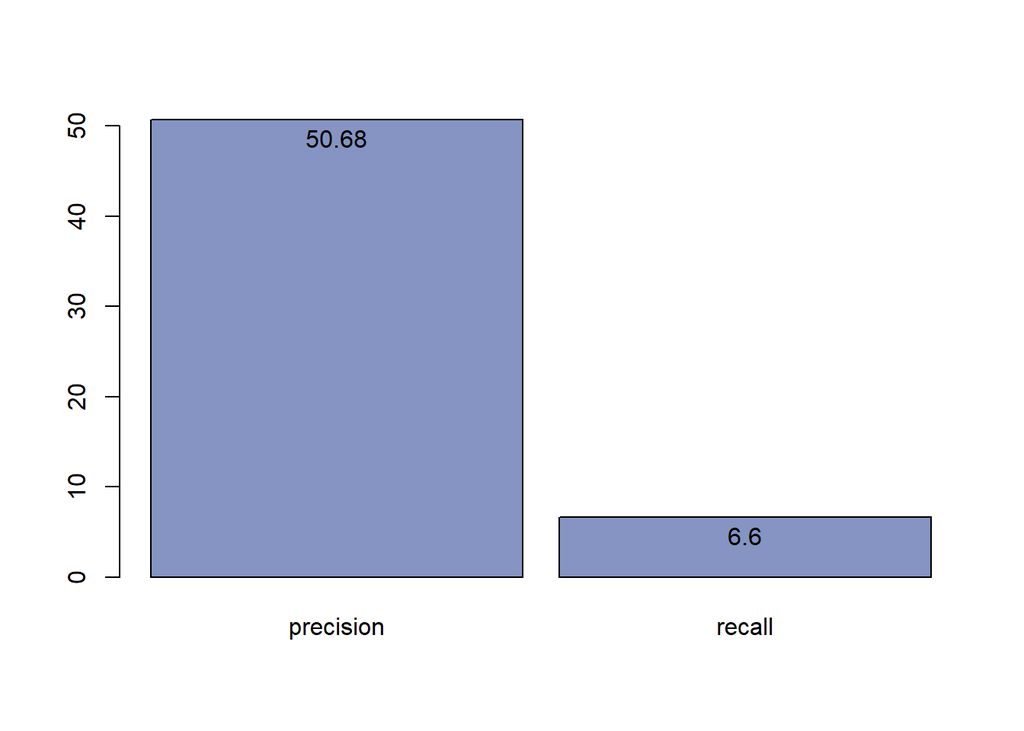

```r
precision <- round(precision(tb[1:2,2:1])*100,2)
recall <- round(recall(tb[1:2,2:1])*100,1)


lg_model_graph <- data.frame(precision , recall )
p <- barplot(as.matrix(lg_model_graph),beside=TRUE, col=rgb(0.2,0.3,0.6,0.6), space = c(0.1, 0.1))
text(x = p, y = lg_model_graph -  2, labels = lg_model_graph)
```

- In my opinion, recall is more important to us as we want to get our false negative down as much as possible. False positives are inclusion errors, while false negatives are exclusion errors. It’s better if we are able to more accurately identify who all are food insecure and need of aid rather than identifying who all are not food insecure and hence don’t need aid.

```r
train$logistic_model1_train.prob <- predict(logistic, train, type = "response")
```

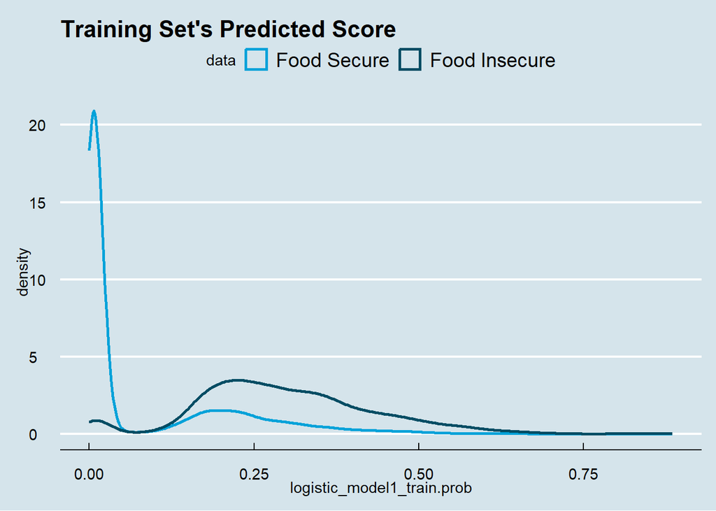

```r
# distribution of the prediction score grouped by known outcome
ggplot( train, aes( logistic_model1_train.prob, color = as.factor(FS_Status) ) ) +
geom_density( size = 1 ) +
ggtitle( "Training Set's Predicted Score" ) +
scale_color_economist( name = "data", labels = c( "Food Secure", "Food Insecure" ) ) +
theme_economist()
```

```r
test$logistic_model1.prob <- logistic_model1.prob
roc_model1 <- roc(FS_Status ~ logistic_model1.prob, data = test)
```

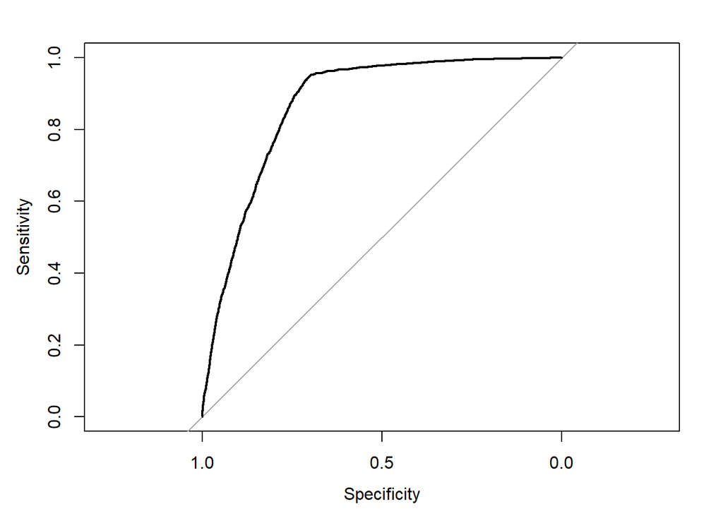

```r
plot(roc_model1)
```

```r
auc(roc_model1)
```

```
## Area under the curve: 0.8699
```

- Changing the cutoff

```r
logistic_model_ncf.prob <- predict(logistic, test, type = "response")
logistic_model_ncf.pred = rep("Food Secure", dim(test)[1])
logistic_model_ncf.pred[logistic_model1.prob > .09] = "Food Insecure"


tb <- table(logistic_model_ncf.pred, test$FS_Status)
tb
```

```
##
## logistic_model_ncf.pred Food Secure Food Insecure
##           Food Insecure        7564          2645
##           Food Secure         18264           163
```

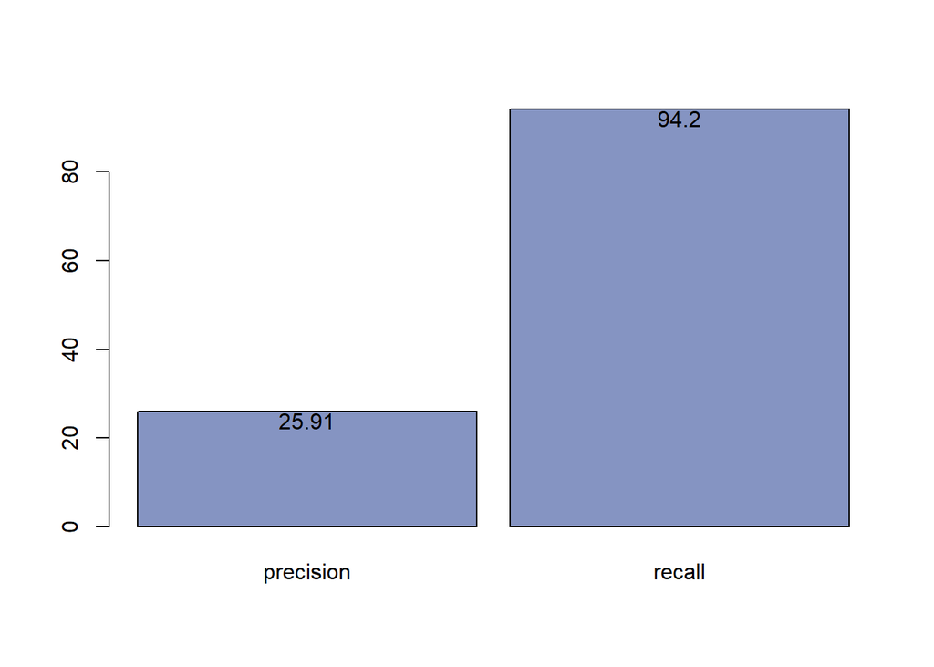

```r
precision <- round(precision(tb[1:2,2:1])*100,2)
recall <- round(recall(tb[1:2,2:1])*100,1)


lg_model_graph <- data.frame(precision , recall )
p <- barplot(as.matrix(lg_model_graph),beside=TRUE, col=rgb(0.2,0.3,0.6,0.6), space = c(0.1, 0.1))
text(x = p, y = lg_model_graph -  2, labels = lg_model_graph)
```

```r
sum(test$FS_Status == "Food Secure")/sum(test$FS_Status == "Food Insecure")
```

```
## [1] 9.198006
```

- So, our model has a 90% classification rate but the ratio of Food secure to Insecure in our data is 9.2. so this is a terrible model that’s as good as tossing a coin. We will have to do something about the imbalance in our response and will have to clean our data further. Since all our variables are categorical of some kind, I highly recommend reading about categorical data modelling to figure out what to do.
- I think doing one-hot encoding(dummy variable) will help in dealing with the level issues in our predictors. We should also combine similar levels so we can reduce the number of levels. also the negative values which correspond to not in the universe or similar have to be dealt with in someway. we can either choose to omit those observation or try to find a proxy for them. I will prefer the latter.
- For the response variable imbalance we can create a new samples where the distribution between the responses is equal. Maybe something like k-fold Cross-Validation would work but I am not sure and would have to read more about it.

#### I am going to be adding weights to the data so our minority class, which is food insecurity, affects the model more.

```r
weight_minority_class = sum(FS_Subset$FS_Status == "Food Secure")/sum(FS_Subset$FS_Status == "Food Insecure")
for(i in seq_len(NROW(FS_Subset))){

if(FS_Subset$FS_Status[i] == "Food Insecure"){
  FS_Subset$Weight[i] = weight_minority_class

}
  else
    FS_Subset$Weight[i] = 1
}

FS_Subset$Weight <- as.numeric(FS_Subset$Weight)
summary(FS_Subset$Weight)
```

```
##    Min. 1st Qu.  Median    Mean 3rd Qu.    Max.
##   1.000   1.000   1.000   1.801   1.000   9.035
```

```r
## Splitting again because train and test doesn't contain the weight column

set.seed(1)

sample <- sample(c(TRUE, FALSE), nrow(FS_Subset), replace = TRUE, prob = c(0.6, 0.4))

train <- FS_Subset[sample, ]
test  <- FS_Subset[!sample, ]
```

```r
logistic_weighted <- glm(FS_Status ~ Ethnicity + States + Family_Size + Household_Income:SNAP + Citizenship_status + Number_of_Jobs + Education_Level   , data = train,  weights = Weight, family = "binomial")
logistic_model2.prob <- predict(logistic_weighted, test, type = "response")
logistic_model2.pred = rep("Food Secure", dim(test)[1])
logistic_model2.pred[logistic_model2.prob > .5] = "Food Insecure"



tb <- table(logistic_model2.pred, test$FS_Status)
tb
```

```
##
## logistic_model2.pred Food Secure Food Insecure
##        Food Insecure        7474          2635
##        Food Secure         18354           173
```

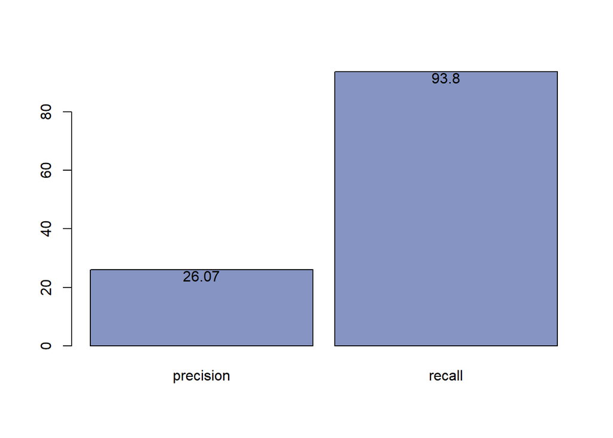

```r
precision <- round(precision(tb[1:2,2:1])*100,2)
recall <- round(recall(tb[1:2,2:1])*100,1)


lg_model_graph <- data.frame(precision , recall )
p <- barplot(as.matrix(lg_model_graph),beside=TRUE, col=rgb(0.2,0.3,0.6,0.6), space = c(0.1, 0.1))
text(x = p, y = lg_model_graph -  2, labels = lg_model_graph)
```

* Our precision for this model is 0.2606588

- Our recall for this model is 0.9383903
- As you can see even though our classification rate of the model went down and the precision of model went down drastically, we were able to raise our recall rate significantly.

```r
test$logistic_model2.prob <- logistic_model2.prob
roc_model2 <- roc(FS_Status ~ logistic_model2.prob, data = test)
```

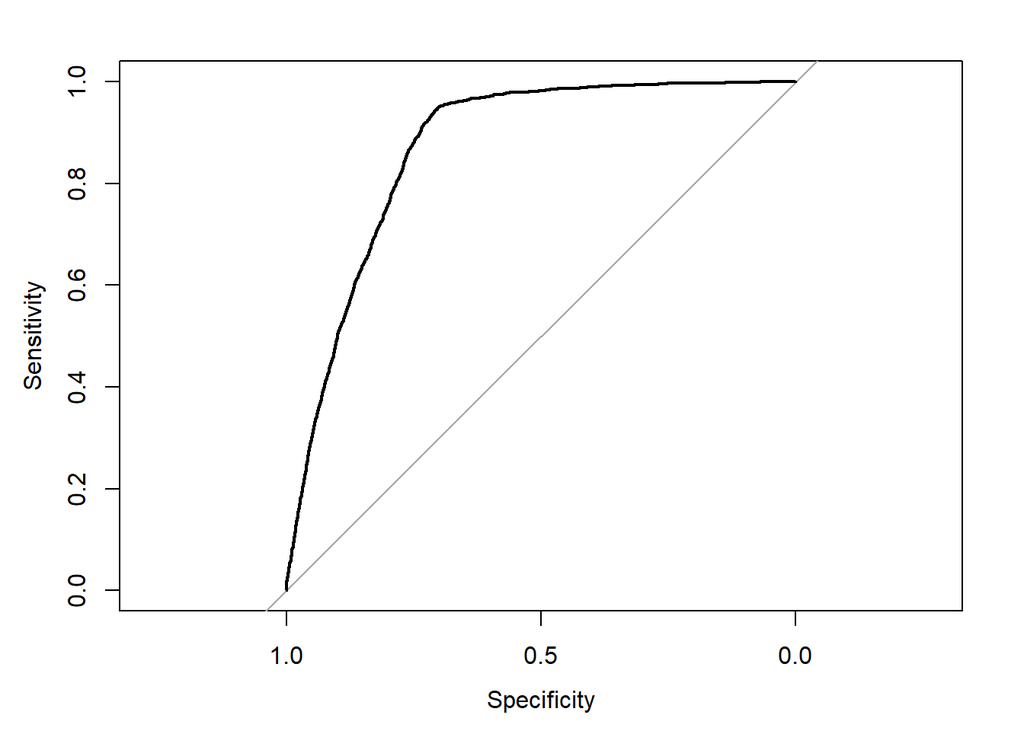

```r
plot(roc_model2)
```

```r
auc(roc_model2)
```

```
## Area under the curve: 0.8695
```

```r
train$logistic_model2_train.prob <- predict(logistic_weighted, train, type = "response")
```

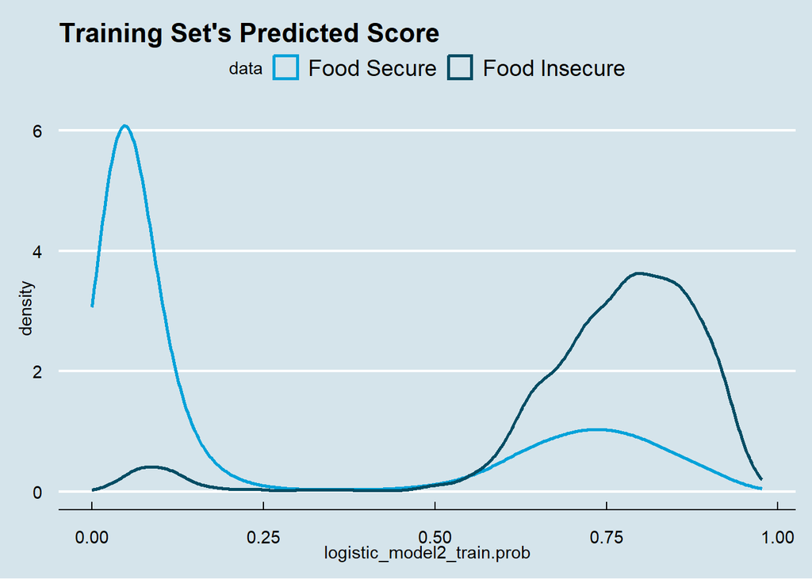

```r
# distribution of the prediction score grouped by known outcome
ggplot( train, aes( logistic_model2_train.prob, color = as.factor(FS_Status) ) ) +
geom_density( size = 1 ) +
ggtitle( "Training Set's Predicted Score" ) +
scale_color_economist( name = "data", labels = c( "Food Secure", "Food Insecure" ) ) +
theme_economist()
```

```r
data.balanced.ou <- ovun.sample(FS_Status~., data=train, p=0.5,  seed=1, method="under")$data
```

```r
logistic_both <- glm(FS_Status ~ Ethnicity + States + Family_Size + Household_Income:SNAP + Citizenship_status + Number_of_Jobs + Education_Level   , data = data.balanced.ou,   family = "binomial")
```

```r
logistic_model3.prob <- predict(logistic_both, test, type = "response")
logistic_model3.pred = rep("Food Secure", dim(test)[1])
logistic_model3.pred[logistic_model3.prob > .5] = "Food Insecure"




tb <- table(logistic_model3.pred, test$FS_Status)
tb
```

```
##
## logistic_model3.pred Food Secure Food Insecure
##        Food Insecure        7526          2628
##        Food Secure         18302           180
```

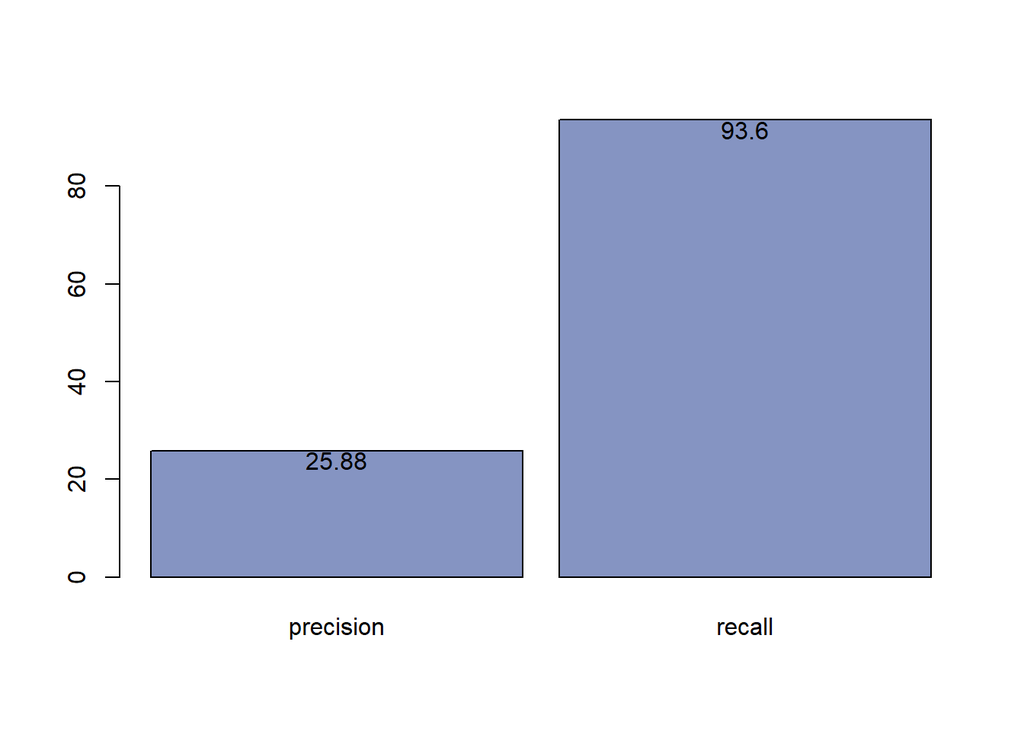

```r
precision <- round(precision(tb[1:2,2:1])*100,2)
recall <- round(recall(tb[1:2,2:1])*100,1)


lg_model_graph <- data.frame(precision , recall )
p <- barplot(as.matrix(lg_model_graph),beside=TRUE, col=rgb(0.2,0.3,0.6,0.6), space = c(0.1, 0.1))
text(x = p, y = lg_model_graph -  2, labels = lg_model_graph)
```

```r
train$logistic_model3_train.prob <- predict(logistic_both, train, type = "response")
```

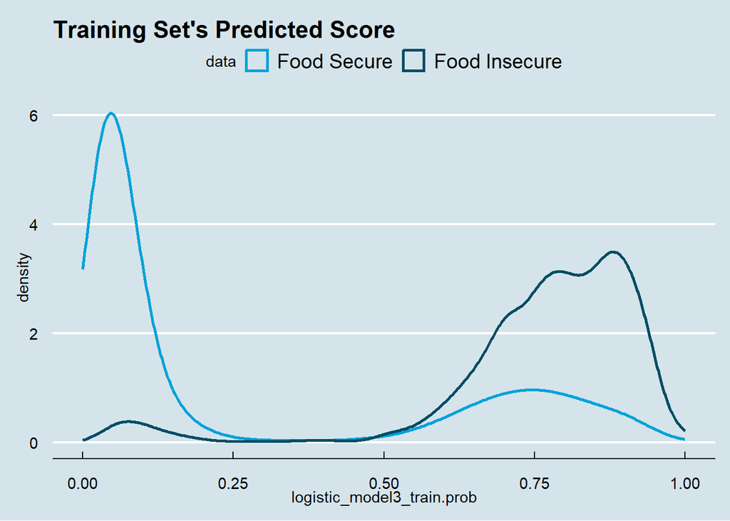

```r
ggplot( train, aes( logistic_model3_train.prob, color = as.factor(FS_Status) ) ) +
geom_density( size = 1 ) +
ggtitle( "Training Set's Predicted Score" ) +
scale_color_economist( name = "data", labels = c( "Food Secure", "Food Insecure" ) ) +
theme_economist()
```

## K-Nearest Neighbours

Here we will try to create a prediction model using KNN Algorithm and we hope to see a model with more accuracy and precision.

# Preparing Data for KNN

```r
str(FS_Subset)
```

```
## 'data.frame':    71442 obs. of  13 variables:
##  $ States            : Factor w/ 51 levels "1","2","4","5",..: 1 1 1 1 1 1 1 1 1 1 ...
##  $ Family_Size       : Factor w/ 14 levels "1","2","3","4",..: 1 2 2 2 2 2 2 2 2 1 ...
##  $ Household_Income  : Factor w/ 16 levels "1","2","3","4",..: 16 14 14 12 12 13 13 9 9 11 ...
##  $ SNAP              : Factor w/ 5 levels "-3","-2","-1",..: 3 3 3 5 5 3 3 5 5 3 ...
##  $ Ethnicity         : Factor w/ 17 levels "White only","Black only",..: 1 1 1 1 1 1 1 2 2 1 ...
##  $ Citizenship_status: Factor w/ 5 levels "NATIVE, BORN IN THE UNITED STATES",..: 1 1 1 1 1 1 1 1 1 1 ...
##  $ Number_of_Jobs    : Factor w/ 4 levels "-1","2","3","4": 1 1 1 1 1 1 1 1 1 1 ...
##  $ Hours_on_Jobs     : Factor w/ 88 levels "-4","-1","0",..: 67 43 2 43 43 62 43 2 2 2 ...
##  $ Education_Level   : Factor w/ 17 levels "-1","31","32",..: 14 15 1 14 14 10 10 7 10 5 ...
##  $ Number_of_children: Factor w/ 12 levels "0","1","2","3",..: 1 2 1 1 1 1 1 1 1 1 ...
##  $ FoodSecurity_score: Factor w/ 4 levels "High Food Security",..: 1 1 1 1 1 1 1 2 2 1 ...
##  $ FS_Status         : Factor w/ 2 levels "Food Secure",..: 1 1 1 1 1 1 1 1 1 1 ...
##  $ Weight            : num  1 1 1 1 1 1 1 1 1 1 ...
```

```r
knn_data <- FS_Subset
knn_data$Family_Size <- as.numeric(FS_Subset$Family_Size)
knn_data$Household_Income <- as.numeric(FS_Subset$Household_Income)
knn_data$Number_of_Jobs <- as.numeric(FS_Subset$Number_of_Jobs)
knn_data$Hours_on_Jobs <- as.numeric(FS_Subset$Hours_on_Jobs)
knn_data$Number_of_children <- as.numeric(FS_Subset$Number_of_children)
knn_data$FS_Status <- as.numeric(FS_Subset$FS_Status)

num_data <- select_if(knn_data, is.numeric)
num_data <- as.data.frame(num_data[-c(7)])
str(num_data)
```

```
## 'data.frame':    71442 obs. of  6 variables:
##  $ Family_Size       : num  1 2 2 2 2 2 2 2 2 1 ...
##  $ Household_Income  : num  16 14 14 12 12 13 13 9 9 11 ...
##  $ Number_of_Jobs    : num  1 1 1 1 1 1 1 1 1 1 ...
##  $ Hours_on_Jobs     : num  67 43 2 43 43 62 43 2 2 2 ...
##  $ Number_of_children: num  1 2 1 1 1 1 1 1 1 1 ...
##  $ FS_Status         : num  1 1 1 1 1 1 1 1 1 1 ...
```

```r
num_data$FS_Status <- replace(num_data$FS_Status, num_data$FS_Status == 1, 3)
num_data$FS_Status <- replace(num_data$FS_Status, num_data$FS_Status == 2, 1)
num_data$FS_Status <- replace(num_data$FS_Status, num_data$FS_Status == 3, 2)


head(num_data)
```

```
##    Family_Size Household_Income Number_of_Jobs Hours_on_Jobs Number_of_children
## 1            1               16              1            67                  1
## 7            2               14              1            43                  2
## 8            2               14              1             2                  1
## 16           2               12              1            43                  1
## 17           2               12              1            43                  1
## 18           2               13              1            62                  1
##    FS_Status
## 1          2
## 7          2
## 8          2
## 16         2
## 17         2
## 18         2
```

```r
tail(num_data)
```

```
##        Family_Size Household_Income Number_of_Jobs Hours_on_Jobs
## 127466           4               11              1             2
## 127467           4               11              1             2
## 127468           4               11              1             2
## 127480           2               12              1             2
## 127481           2               12              1            39
## 127486           1               12              1             2
##        Number_of_children FS_Status
## 127466                  2         1
## 127467                  1         1
## 127468                  1         1
## 127480                  1         2
## 127481                  1         2
## 127486                  1         2
```

```r
library(ROSE)
```

```r
data_balanced_under <- as.data.frame(ovun.sample(FS_Status ~ ., data = num_data, method = "both", N = nrow(num_data), seed = 1)$data)
table(data_balanced_under$cls)
```

```
## < table of extent 0 >
```

```r
str(data_balanced_under)
```

```
## 'data.frame':    71442 obs. of  6 variables:
##  $ Family_Size       : num  1 3 2 2 2 5 6 4 6 7 ...
##  $ Household_Income  : num  7 9 6 14 16 16 16 12 15 14 ...
##  $ Number_of_Jobs    : num  1 1 1 1 1 1 1 1 1 1 ...
##  $ Hours_on_Jobs     : num  1 2 2 2 43 18 2 53 2 43 ...
##  $ Number_of_children: num  1 1 1 1 1 1 1 1 1 6 ...
##  $ FS_Status         : num  2 2 2 2 2 2 2 2 2 2 ...
```

```r
head(data_balanced_under)
```

```
##   Family_Size Household_Income Number_of_Jobs Hours_on_Jobs Number_of_children
## 1           1                7              1             1                  1
## 2           3                9              1             2                  1
## 3           2                6              1             2                  1
## 4           2               14              1             2                  1
## 5           2               16              1            43                  1
## 6           5               16              1            18                  1
##   FS_Status
## 1         2
## 2         2
## 3         2
## 4         2
## 5         2
## 6         2
```

```r
tail(data_balanced_under)
```

```
##       Family_Size Household_Income Number_of_Jobs Hours_on_Jobs
## 71437           3                6              1            28
## 71438           2                8              1             2
## 71439           2               12              2            53
## 71440           6               10              1             2
## 71441           1                6              1             2
## 71442           5               12              1            23
##       Number_of_children FS_Status
## 71437                  3         1
## 71438                  1         1
## 71439                  1         1
## 71440                  1         1
## 71441                  1         1
## 71442                  3         1
```

```r
num_data <- data_balanced_under
```

First we want to scale and center the data to ensure KNN will operate correctly.

```r
scaledata <- as.data.frame(scale(num_data, center = TRUE, scale = TRUE))
```

We also need to create test and train data sets, we will do this slightly differently by using the sample function. The 2 says create 2 data sets essentially, replacement means we can reset the random sampling across each vector and the probability gives sample the weight of the splits, 2/3 for train, 1/3 for test.

```r
set.seed(1000)
knn_sample <- sample(2, nrow(scaledata), replace=TRUE, prob=c(0.67, 0.33))
```

```r
knn_training <- scaledata[knn_sample==1, 1:5]
knn_test <- scaledata[knn_sample==2, 1:5]
```

Now we need to create our Y variables or labels need to input into the KNN function.

```r
knn.trainLabels <- num_data[knn_sample==1, 6]
knn.testLabels <- num_data[knn_sample==2, 6]
```

```r
# Loading package
library(e1071)
library(caTools)
library(class)
loadPkg("gmodels")
loadPkg("gmodels")
loadPkg("FNN")
loadPkg("caret")
```

# Building Models

```r
library(class)
knn_pred <- knn(train = knn_training, test = knn_test, cl=knn.trainLabels, k=3)
#knn_pred
```

```r
knn_crosst <- gmodels::CrossTable(knn.testLabels, train = knn_pred, prop.chisq = FALSE)
```

```
##
##
##    Cell Contents
## |-------------------------|
## |                       N |
## |         N / Table Total |
## |-------------------------|
##
##
## Total Observations in Table:  23420
##
##
##           |         1 |         2 |
##           |-----------|-----------|
##           |     11719 |     11701 |
##           |     0.500 |     0.500 |
##           |-----------|-----------|
##
##
##
##
```

```r
# create an empty dataframe to store the results from confusion matrices
ResultDf = data.frame( k=numeric(0), Total.Accuracy= numeric(0), row.names = NULL )
kval = 3
knn_pred <- knn(train = knn_training, test = knn_test, cl=knn.trainLabels, k=kval)

knn_crosst <- gmodels::CrossTable(knn.testLabels, train = knn_pred, prop.chisq = FALSE)
```

```
##
##
##    Cell Contents
## |-------------------------|
## |                       N |
## |         N / Table Total |
## |-------------------------|
##
##
## Total Observations in Table:  23420
##
##
##           |         1 |         2 |
##           |-----------|-----------|
##           |     11719 |     11701 |
##           |     0.500 |     0.500 |
##           |-----------|-----------|
##
##
##
##
```

```r
print( paste("k = ", kval) )
```

```
## [1] "k =  3"
```

```r
knn_crosst
```

```
## $t
##          1     2
## [1,] 11719 11701
##
## $prop.row
##              1         2
## [1,] 0.5003843 0.4996157
##
## $prop.col
##      1 2
## [1,] 1 1
##
## $prop.tbl
##              1         2
## [1,] 0.5003843 0.4996157
```

```r
library(caret)
cm <- confusionMatrix(knn_pred, reference = as.factor(knn.testLabels) )

# print.confusionMatrix(cm)
#
cmaccu = cm$overall['Accuracy']
print( paste("Total Accuracy = ", cmaccu ) )
```

```
## [1] "Total Accuracy =  0.711571306575576"
```

```r
# print("Other metrics : ")
# print(cm$byClass)
#
cmt = data.frame(k=kval, Total.Accuracy = cmaccu, row.names = NULL ) # initialize a row of the metrics
# cmt = cbind( cmt, data.frame( t(cm$byClass) ) ) # the dataframe of the transpose, with k valued added in front
ResultDf = rbind(ResultDf, cmt)
print( xkabledply(   as.matrix(cm), title = paste("ConfusionMatrix for k = ",kval ) ) )
```

```
## <table class="table table-striped" style="width: auto !important; ">
## <caption>ConfusionMatrix for k =  3</caption>
##  <thead>
##   <tr>
##    <th style="text-align:right;"> 1 </th>
##    <th style="text-align:right;"> 2 </th>
##   </tr>
##  </thead>
## <tbody>
##   <tr>
##    <td style="text-align:right;"> 8672 </td>
##    <td style="text-align:right;"> 3708 </td>
##   </tr>
##   <tr>
##    <td style="text-align:right;"> 3047 </td>
##    <td style="text-align:right;"> 7993 </td>
##   </tr>
## </tbody>
## </table>
```

```r
# print("Other metrics : ")
# print(cm$byClass)
#
cmt = data.frame(k=kval, Total.Accuracy = cmaccu, row.names = NULL ) # initialize a row of the metrics
# cmt = cbind( cmt, data.frame( t(cm$byClass) ) ) # the dataframe of the transpose, with k valued added in front
ResultDf = rbind(ResultDf, cmt)
print( xkabledply(   as.matrix(cm), title = paste("ConfusionMatrix for k = ",kval ) ) )
```

```
## <table class="table table-striped" style="width: auto !important; ">
## <caption>ConfusionMatrix for k =  3</caption>
##  <thead>
##   <tr>
##    <th style="text-align:right;"> 1 </th>
##    <th style="text-align:right;"> 2 </th>
##   </tr>
##  </thead>
## <tbody>
##   <tr>
##    <td style="text-align:right;"> 8672 </td>
##    <td style="text-align:right;"> 3708 </td>
##   </tr>
##   <tr>
##    <td style="text-align:right;"> 3047 </td>
##    <td style="text-align:right;"> 7993 </td>
##   </tr>
## </tbody>
## </table>
```

```r
print( xkabledply(data.frame(cm$byClass), title=paste("k = ",kval)) )
```

```
## <table class="table table-striped" style="width: auto !important; ">
## <caption>k =  3</caption>
##  <thead>
##   <tr>
##    <th style="text-align:left;">   </th>
##    <th style="text-align:right;"> cm.byClass </th>
##   </tr>
##  </thead>
## <tbody>
##   <tr>
##    <td style="text-align:left;"> Sensitivity </td>
##    <td style="text-align:right;"> 0.7400 </td>
##   </tr>
##   <tr>
##    <td style="text-align:left;"> Specificity </td>
##    <td style="text-align:right;"> 0.6831 </td>
##   </tr>
##   <tr>
##    <td style="text-align:left;"> Pos Pred Value </td>
##    <td style="text-align:right;"> 0.7005 </td>
##   </tr>
##   <tr>
##    <td style="text-align:left;"> Neg Pred Value </td>
##    <td style="text-align:right;"> 0.7240 </td>
##   </tr>
##   <tr>
##    <td style="text-align:left;"> Precision </td>
##    <td style="text-align:right;"> 0.7005 </td>
##   </tr>
##   <tr>
##    <td style="text-align:left;"> Recall </td>
##    <td style="text-align:right;"> 0.7400 </td>
##   </tr>
##   <tr>
##    <td style="text-align:left;"> F1 </td>
##    <td style="text-align:right;"> 0.7197 </td>
##   </tr>
##   <tr>
##    <td style="text-align:left;"> Prevalence </td>
##    <td style="text-align:right;"> 0.5004 </td>
##   </tr>
##   <tr>
##    <td style="text-align:left;"> Detection Rate </td>
##    <td style="text-align:right;"> 0.3703 </td>
##   </tr>
##   <tr>
##    <td style="text-align:left;"> Detection Prevalence </td>
##    <td style="text-align:right;"> 0.5286 </td>
##   </tr>
##   <tr>
##    <td style="text-align:left;"> Balanced Accuracy </td>
##    <td style="text-align:right;"> 0.7115 </td>
##   </tr>
## </tbody>
## </table>
```

# Different K-values

```r
for (kval in 4:11) {
  knn_pred <- knn(train = knn_training, test = knn_test, cl=knn.trainLabels, k=kval)
  knn_crosst <- CrossTable(knn.testLabels, knn_pred, prop.chisq = FALSE)
  print( paste("k = ", kval) )
  knn_crosst
  #
  cm = confusionMatrix(knn_pred, reference = as.factor(knn.testLabels )) # from caret library
  # print.confusionMatrix(cm)
  #
  cmaccu = cm$overall['Accuracy']
  print( paste("Total Accuracy = ", cmaccu ) )
  # print("Other metrics : ")
  # print(cm$byClass)
  #
  cmt = data.frame(k=kval, Total.Accuracy = cmaccu, row.names = NULL ) # initialize a row of the metrics
  # cmt = cbind( cmt, data.frame( t(cm$byClass) ) ) # the dataframe of the transpose, with k valued added in front
  ResultDf = rbind(ResultDf, cmt)
  print( xkabledply(   as.matrix(cm), title = paste("ConfusionMatrix for k = ",kval ) ) )
  print( xkabledply(data.frame(cm$byClass), title=paste("k = ",kval)) )
}
```

```
##
##
##    Cell Contents
## |-------------------------|
## |                       N |
## |           N / Row Total |
## |           N / Col Total |
## |         N / Table Total |
## |-------------------------|
##
##
## Total Observations in Table:  23420
##
##
##                | knn_pred
## knn.testLabels |         1 |         2 | Row Total |
## ---------------|-----------|-----------|-----------|
##              1 |      9851 |      1868 |     11719 |
##                |     0.841 |     0.159 |     0.500 |
##                |     0.672 |     0.213 |           |
##                |     0.421 |     0.080 |           |
## ---------------|-----------|-----------|-----------|
##              2 |      4807 |      6894 |     11701 |
##                |     0.411 |     0.589 |     0.500 |
##                |     0.328 |     0.787 |           |
##                |     0.205 |     0.294 |           |
## ---------------|-----------|-----------|-----------|
##   Column Total |     14658 |      8762 |     23420 |
##                |     0.626 |     0.374 |           |
## ---------------|-----------|-----------|-----------|
##
##
## [1] "k =  4"
## [1] "Total Accuracy =  0.714987190435525"
## <table class="table table-striped" style="width: auto !important; ">
## <caption>ConfusionMatrix for k =  4</caption>
##  <thead>
##   <tr>
##    <th style="text-align:right;"> 1 </th>
##    <th style="text-align:right;"> 2 </th>
```

[output cut: 794 more lines]

```
##   </tr>
##   <tr>
##    <td style="text-align:left;"> Detection Rate </td>
##    <td style="text-align:right;"> 0.3892 </td>
##   </tr>
##   <tr>
##    <td style="text-align:left;"> Detection Prevalence </td>
##    <td style="text-align:right;"> 0.5573 </td>
##   </tr>
##   <tr>
##    <td style="text-align:left;"> Balanced Accuracy </td>
##    <td style="text-align:right;"> 0.7207 </td>
##   </tr>
## </tbody>
## </table>
```

```r
xkabledply(ResultDf, "Total Accuracy Summary")
```

Total Accuracy Summary

| k | Total.Accuracy |
| --- | --- |
| 3 | 0.7116 |
| 3 | 0.7116 |
| 4 | 0.7150 |
| 5 | 0.7230 |
| 6 | 0.7228 |
| 7 | 0.7183 |
| 8 | 0.7206 |
| 9 | 0.7175 |
| 10 | 0.7201 |
| 11 | 0.7208 |